# R Lab 1: Welcome to Posit Cloud!

Author

Grading Rubric

[output not shown]

## Quarto Text Formatting

This is a Quarto document. Quarto is a simple formatting syntax for authoring HTML, PDF, and Microsoft Word documents.

The document may look a bit different that you are used to, but we will break it down!

Section headers are defined with hashtags (#), where one # is the largest header, two ## is the second largest and so on.

You can make words boldface with two ** (like **so**).

You can make words italicized with one * (like *this*).

You can make lists like this:

- item 1
- item 2
- item 3

(Notice you need to have a blank line before the first item of your list!)

## R Code

You can differentiate the R code within an Quarto file from the body of the document, from the three tickmarks (```) they start and end with.

Notice that after the ``` you see a curly brace with an “r” in it ({r}), this indicates to RMarkdown that the code inside of that code chunk is R code (not Python code or another type of code).

Also, the “setup” after the “r” is the code chunk’s name. It is good practice to name your code chunks based on the action they perform. It makes it easier to navigate to them in the navigation pane.

1. **What does the library() function do?**

   `library` is a function that loads a package.
2. **What is the tidyverse?**

   The `tidyverse` is a collection of R packages designed for data science.

## Rendering

3. **Why do you not see the above code chunk (named `setup`) when you render the document?**

   The setup code chunk includes an option `#| include = false` which prevents code and results from appearing in the rendered file.

## Including Code Output

You can include code output in your rendered document:

```r
head(mpg)
```

```
# A tibble: 6 × 11
  manufacturer model displ  year   cyl trans      drv     cty   hwy fl    class
  <chr>        <chr> <dbl> <int> <int> <chr>      <chr> <int> <int> <chr> <chr>
1 audi         a4      1.8  1999     4 auto(l5)   f        18    29 p     compa…
2 audi         a4      1.8  1999     4 manual(m5) f        21    29 p     compa…
3 audi         a4      2    2008     4 manual(m6) f        20    31 p     compa…
4 audi         a4      2    2008     4 auto(av)   f        21    30 p     compa…
5 audi         a4      2.8  1999     6 auto(l5)   f        16    26 p     compa…
6 audi         a4      2.8  1999     6 manual(m5) f        18    26 p     compa…
```

4. **What do you think the `head()` function does?** *(Hint: What kind of output does it give you?)*

   The `head` function prints out the first 6 rows of the data set.

## Loading Data into `R`

You can load data files into R using functions from different packages. You will learn that the function you use depends on what format the data are in. Today, we will work with data that are stored in a Comma Separated Values file (a CSV). For this format of data, we will use the `read_csv()` function to read in our data.

```r
# Your code for question 5 goes below this line!
head(arson_data)
```

```
# A tibble: 6 × 7
  Question Question_Text             Crime_Scene_Answer Suspect_Response Outcome
     <dbl> <chr>                     <lgl>              <lgl>            <chr>
1        1 One of the fires was sta… FALSE              FALSE            Correct
2        2 Matches were used to set… TRUE               TRUE             Correct
3        3 The trash was on the cur… FALSE              TRUE             Incorr…
4        4 There was a doghouse in … FALSE              FALSE            Correct
5        5 The residence of the thi… TRUE               TRUE             Correct
6        6 The second residence had… TRUE               FALSE            Incorr…
# ℹ 2 more variables: Time_to_Response_seconds <dbl>,
#   Action_During_Response <chr>
```

```r
glimpse(arson_data)
```

```
Rows: 16
Columns: 7
$ Question                 <dbl> 1, 2, 3, 4, 5, 6, 7, 8, 9, 10, 11, 12, 13, 14…
$ Question_Text            <chr> "One of the fires was started using gasoline.…
$ Crime_Scene_Answer       <lgl> FALSE, TRUE, FALSE, FALSE, TRUE, TRUE, TRUE, …
$ Suspect_Response         <lgl> FALSE, TRUE, TRUE, FALSE, TRUE, FALSE, TRUE, …
$ Outcome                  <chr> "Correct", "Correct", "Incorrect", "Correct",…
$ Time_to_Response_seconds <dbl> 30, 12, 38, 29, 14, 45, 22, 24, 15, 32, 20, 1…
$ Action_During_Response   <chr> "Eye contact", "Scratching", "Shaking", "Scra…
```

```r
names(arson_data)
```

```
[1] "Question"                 "Question_Text"
[3] "Crime_Scene_Answer"       "Suspect_Response"
[5] "Outcome"                  "Time_to_Response_seconds"
[7] "Action_During_Response"
```

6. **What are the observations in this data set?**

   A question given to the suspect.
7. **How many observations are there in the data set?** *Hint: you can use code to find this or look in the top right environment.*

   16 questions (rows in the data set)
8. **What are the variables in this data set? What are their data types?**

   7 Variables

## Including Plots

You can also embed plots in the rendered document. Here is an example of a plot:

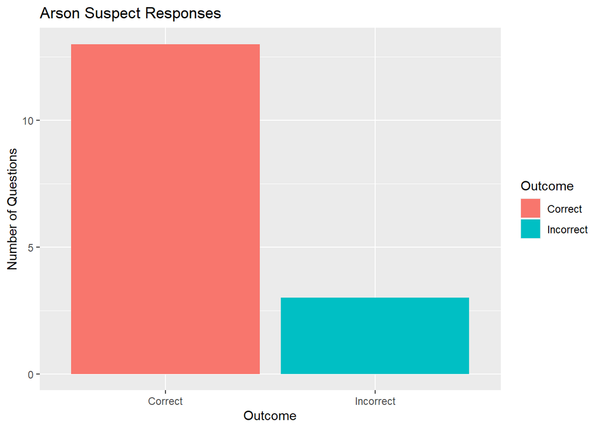

8. **What do you think the `#| echo: false` option does in the above code chunk?**

   Prevents code, but not results from appearing in the rendered file.